# download-2009

To identify the ecoregion for each observation, we need to join the eco_gdf and gbif_gdf together. The joined data is a new variable called gbif_ecoregion_gdf

```python
gbif_ecoregion_gdf = (
    eco_gdf
    # Match the CRS of the GBIF data and the ecoregions
    .to_crs(gbif_gdf.crs)
    # Find ecoregion for each observation
    .sjoin(
        gbif_gdf,
        how='inner',
        predicate='contains')
)
gbif_ecoregion_gdf
```

| ecoregion_id | name | area | geometry | gbifID | month |
| --- | --- | --- | --- | --- | --- |
| 13.0 | Alberta-British Columbia foothills forests | 17.133639 | MULTIPOLYGON (((-119.53979 55.81661, -119.5443... | 3269620424 | 9.0 |
| 13.0 | Alberta-British Columbia foothills forests | 17.133639 | MULTIPOLYGON (((-119.53979 55.81661, -119.5443... | 1205984752 | 6.0 |
| 13.0 | Alberta-British Columbia foothills forests | 17.133639 | MULTIPOLYGON (((-119.53979 55.81661, -119.5443... | 5425832666 | 5.0 |
| 13.0 | Alberta-British Columbia foothills forests | 17.133639 | MULTIPOLYGON (((-119.53979 55.81661, -119.5443... | 5531404701 | 5.0 |
| 13.0 | Alberta-British Columbia foothills forests | 17.133639 | MULTIPOLYGON (((-119.53979 55.81661, -119.5443... | 5706956904 | 5.0 |
| ... | ... | ... | ... | ... | ... |
| 839.0 | Northern Rockies conifer forests | 35.905513 | POLYGON ((-119.99977 54.53117, -119.8914 54.45... | 256767436 | 7.0 |
| 839.0 | Northern Rockies conifer forests | 35.905513 | POLYGON ((-119.99977 54.53117, -119.8914 54.45... | 256438480 | 7.0 |
| 839.0 | Northern Rockies conifer forests | 35.905513 | POLYGON ((-119.99977 54.53117, -119.8914 54.45... | 256317445 | 6.0 |
| 839.0 | Northern Rockies conifer forests | 35.905513 | POLYGON ((-119.99977 54.53117, -119.8914 54.45... | 599681238 | 6.0 |
| 839.0 | Northern Rockies conifer forests | 35.905513 | POLYGON ((-119.99977 54.53117, -119.8914 54.45... | 599682307 | 6.0 |

34229 rows × 5 columns

Count observations in each ecoregion each month

```python
# Count the observations in each ecoregion each month
occurrence_df = (
    gbif_ecoregion_gdf
    # Reset index
    .reset_index()
    # For each ecoregion, for each month...
    .groupby(['ecoregion_id','month'])
    # ...count the number of occurrences
    # creating a new column 'occurrences' that counts all the gbif IDs in a group
    .agg(
        occurrences=('gbifID', 'count'),
        area=('area','first'))
)
```

Normalize by area

This step gives us a new column called "density" which shows the number of occurrences divided by the ecoregion area. Not all ecoregions are the same size, so this step accounts for this. The density column gives us a count of the number of occurences for a given unit area.

```python
#Normalize by area
occurrence_df['density'] = (
    occurrence_df.occurrences
    / occurrence_df.area
)

# Get rid of rare observations (possible misidentification?)
occurrence_df = occurrence_df[occurrence_df.occurrences>1]
```

Take the mean by ecoregion

Gives us the mean number of occurrences in an ecoregion.

```python
# Take the mean by ecoregion
mean_occurrences_by_ecoregion = (
    occurrence_df
    .groupby('ecoregion_id')
    .mean()
)
mean_occurrences_by_ecoregion
```

| ecoregion_id | occurrences | area | density |
| --- | --- | --- | --- |
| 13.0 | 6.666667 | 17.133639 | 0.389098 |
| 17.0 | 118.714286 | 7.958751 | 14.916196 |
| 23.0 | 3.600000 | 3.346216 | 1.075842 |
| 33.0 | 182.428571 | 16.637804 | 10.964703 |
| 34.0 | 104.714286 | 18.674884 | 5.607226 |
| ... | ... | ... | ... |
| 821.0 | 9.000000 | 26.034401 | 0.345696 |
| 827.0 | 2.000000 | 9.664680 | 0.206939 |
| 833.0 | 12.428571 | 0.610793 | 20.348238 |
| 838.0 | 6.000000 | 4.286144 | 1.399860 |
| 839.0 | 44.200000 | 35.905513 | 1.231009 |

133 rows × 3 columns

Take the mean by month

Gives us the mean number of occurrences in a given month

```python
# Take the mean by month
mean_occurrences_by_month = (
    occurrence_df
    .groupby('month')
    .mean()
)
mean_occurrences_by_month
```

| month | occurrences | area | density |
| --- | --- | --- | --- |
| 1.0 | 8.414634 | 3.946549 | 34.251673 |
| 2.0 | 8.714286 | 5.638937 | 5.759934 |
| 3.0 | 8.756757 | 4.923813 | 8.343091 |
| 4.0 | 32.644444 | 10.337087 | 7.115234 |
| 5.0 | 183.621212 | 19.332582 | 17.410522 |
| 6.0 | 93.618182 | 23.795967 | 6.333724 |
| 7.0 | 51.365854 | 26.555008 | 3.139044 |
| 8.0 | 57.519231 | 22.281602 | 6.707274 |
| 9.0 | 102.031250 | 17.284795 | 33.416582 |
| 10.0 | 31.453125 | 10.457288 | 67.876760 |
| 11.0 | 9.971429 | 6.995604 | 38.831634 |
| 12.0 | 8.075000 | 4.866798 | 24.591023 |

Normalize by space and time for sampling effort

The goal of this step is to remove systematic differences such as some months have more sampling efforts because more birdwatchers are outside, and some regions are more heavily surveyed.

The goal of the new column, "norm_occurrences" is to give an occurrence count that is normalized for space and time differences.

```python
# Normalize by space and time for sampling effort
occurrence_df['norm_occurrences'] = (
    occurrence_df[['density']]
    / mean_occurrences_by_ecoregion[['density']]
    / mean_occurrences_by_month[['density']]
)
occurrence_df
```

| ecoregion_id | month | occurrences | area | density | norm_occurrences |
| --- | --- | --- | --- | --- | --- |
| 13.0 | 5.0 | 5 | 17.133639 | 0.291824 | 0.043077 |
|  | 6.0 | 13 | 17.133639 | 0.758741 | 0.307876 |
|  | 7.0 | 2 | 17.133639 | 0.116729 | 0.095570 |
| 17.0 | 4.0 | 23 | 7.958751 | 2.889901 | 0.027229 |
|  | 5.0 | 365 | 7.958751 | 45.861469 | 0.176595 |
| ... | ... | ... | ... | ... | ... |
| 839.0 | 5.0 | 16 | 35.905513 | 0.445614 | 0.020792 |
|  | 6.0 | 120 | 35.905513 | 3.342105 | 0.428647 |
|  | 7.0 | 57 | 35.905513 | 1.587500 | 0.410823 |
|  | 8.0 | 23 | 35.905513 | 0.640570 | 0.077582 |
|  | 9.0 | 5 | 35.905513 | 0.139254 | 0.003385 |

582 rows × 4 columns

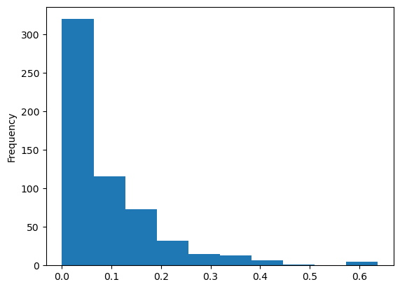

```python
occurrence_df.norm_occurrences.plot.hist()
```

**Figure 1:** This histogram plot shows that there is a higher frequency of normalized ecoregions with low occurrence values, and fewer ecoregions with higher occurrence values.

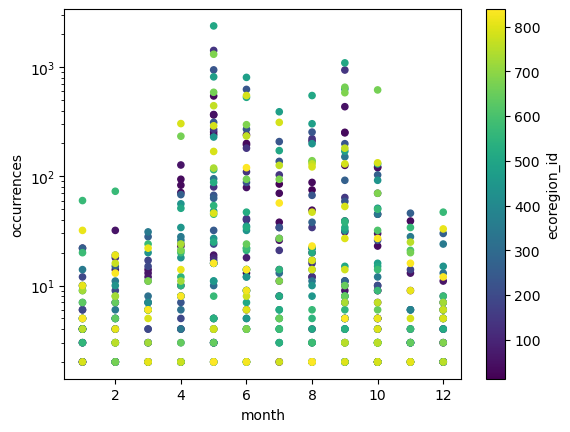

```python
# Plotting a scatter with regular "occurrences" by month
occurrence_df.reset_index().plot.scatter(
    x='month', y='occurrences', c='ecoregion_id', logy=True
)
```

**Figure 2:** Plot showing the un-normalized occurrence data of the number of bird observations.

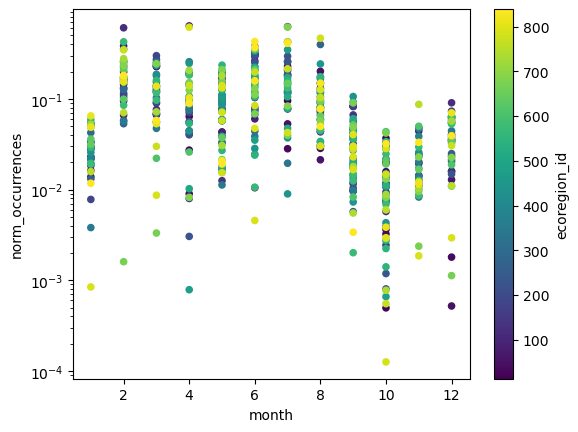

```python
# Plotting a scatter with normalized occurrences by month
occurrence_df.reset_index().plot.scatter(
    x='month', y='norm_occurrences', c='ecoregion_id', logy=True
)
```

**Figure 3:** Plot showing normallized occurrence data across the months.

```python
# Simplify the geometry to speed up processing
eco_gdf.geometry = eco_gdf.simplify(.1, preserve_topology=False)

# Change the CRS to Mercator for mapping
eco_gdf = eco_gdf.to_crs(ccrs.Mercator())

# Check that the plot runs in a reasonable amount of time
eco_gdf.hvplot(geo=True, crs=ccrs.Mercator())
```

[output not shown]

Create an interactive plot of the migration data

Note: The plot will not display in the HTML version of this notebook.

```python
# Join the occurrences with the plotting GeoDataFrame
occurrence_gdf = eco_gdf.join(occurrence_df[['norm_occurrences']])

# Remove any empty geometry rows. These can cause errors if they persist in the data.
occurrence_gdf = occurrence_gdf[~occurrence_gdf.geometry.is_empty]

# Get the plot bounds so they don't change with the slider
# xmin, ymin, xmax, ymax = gbif_gdf.to_crs(ccrs.Mercator()).total_bounds

# This code above will plot the entire range of the data (even other continents/unusual sightings)
# I am just interested in the South-North American data, so I set the bounds manually.

xmin = -35000000.0
xmax = -2000000.0
ymax = 11000000.0
ymin = -4000000.0

# List month names on the slider
month_widget = pn.widgets.DiscreteSlider(
    options={
        calendar.month_name[month_num]: month_num
        for month_num in range(1,13)
    }
)

# Plot occurrence by ecoregion and month
migration_plot = (
    occurrence_gdf
    .hvplot(
        c='norm_occurrences',
        groupby='month',
        # Use background tiles
        geo=True, crs=ccrs.Mercator(), tiles='CartoLight',
        title="American Redstart Migration, 2009",
        xlim=(xmin, xmax), ylim=(ymin, ymax),
        frame_height=220,
        frame_width=220,
        widgets={'month': month_widget},
        widget_location='bottom'
    )
)

# Save the plot
migration_plot.save('redstart-migration-2009.html', embed=True)
# Display the plot
migration_plot
```

```
WARNING:W-1005 (FIXED_SIZING_MODE): 'fixed' sizing mode requires width and height to be set: figure(id='p11486', ...)
```

[output not shown]

```python
occurrence_gdf.to_file("redstart_occurrence_2009.geojson", driver="GeoJSON")
```

```
INFO:Created 576 records
```